# 6 How and Why to Use Models

Before we dive into methods, it will be helpful to review a number of important use cases for quantitative economic models. Why use a model? This might seem like a strange question to devote time to, given that there is no such thing as economics without them. Still, when you are out in the world presenting your research, you may sometimes encounter this question. Indeed, you will read many important and useful applied papers that have no need of an economic model, so it’s not so surprising to think that there are research questions that do not demand a structural estimation exercise. What is my model for? How is it central to answering my research question?

## 6.1 When you possibly don’t need a model.

A lot of students, when they write their first paper, end up posing simple questions like “What is the effect of policy $X$ on outcome $Y$”? Often, answering these questions requires nothing more than simple statistical models of causality (such as the [Potential Outcomes Model](https://en.wikipedia.org/wiki/Rubin_causal_model) or the Generalized Roy Model, which formalize causality in terms of potential outcomes).

In particular, if your question concerns the causal effect of an observed historical change in some variable, you likely won’t anything more elaborate than these simple frameworks. Consider below three examples of quasi-experimental variation from our prototype models that answer particular research questions without needing specification of the underlying models.

### 6.1.1 Social Security

In the life-cycle savings model, consider the inclusion of a social security system that provides income at older ages. The budget constraint becomes:

$$c_{t} + a_{t+1}/(1 + r) \leq (1-\tau)y_{t} + \mathbf{1}\{t\geq 65\}b$$

so that individuals become eligible for a benefit, $b$, after age 65, and pay into the system with proportional taxes, $\tau$.

Suppose that the age of eligibility for social security is decreased, unexpectedly, from 65 to 60. Suppose also you have data on consumption for two cohorts, $A$, and $B$. Cohort $A$ was not exposed to this change (they reached age 65 before becoming eligible), while cohort $B$ is exactly aged 60 when the change is announced. **Suppose your question is**: *“What was the effect of this eligibility expansion on consumption of cohort $B$ at each age after 60-64?”* This question can be answered without specifying the full economic model and imposing a simpler set of assumption on potential outcomes: parallel trends. Let $D\in\{0,1\}$ indicate exposure to the treatment (learning of the policy change at age 60). Parallel trends is an assumption on the counterfactual for cohort $B$:
$$\mathbb{E}[C|B,D=0,t] = \gamma_{B} + \mathbb{E}[C|A,D=0,t]$$
it says that these two cohorts, in the absence of the treatment, would differ, but these differences would be constant with age. This allows us an estimate of the causal effect using observations for any age $s<60$:
$$\mathbb{E}[C|B,D=1,t] - \mathbb{E}[C|B,D=0,t] = \mathbb{E}[C|B,t] - \mathbb{E}[C|A,t] - \left(\mathbb{E}[C|B,s] - \mathbb{E}[C|A,s]\right)$$
Notice that the left-hand side defines the causal effect of eligibility on consumption via a *counterfactual* and the right-hand side consists only of estimable quantities.

We have only to defend the parallel trends assumption, which many view as less burdensome compared to defending the many layers of assumptions in a quantitative model. In general, letting $t^*$ index the age of an individual when the policy is announced (so that $B$ is cohort $t^*=60$), the parallel trends assumption allows us to write:
$$\mathbb{E}[C_{t^*,t}] = \gamma_{t^*} + \mu_{t} + \alpha_{t^*,t}\mathbf{1}\{t\geq t^*\}$$
where $\alpha_{t^*,t}$ is the effect of learning about the policy expansion at age $t^*$ on consumption at age $t$. This imposes parallel trends across every single cohort, even ones that are not particular adjacent to each other, which is arguably a much stronger assumption.

### 6.1.2 Firm Entry

Consider the firm entry model. Suppose you have panel data $(A_{m,t,1},A_{m,t,2},Z_{m,t})_{m=1,t=1}^{M,T}$ on a set of markets (indexed by $m$) in a number of periods (indexed by $t$). Recall that $A_{m,t,j}$ indicates whether firm $j$ is active in market $m$ at time $t$, and firm entry occurs when $A_{m,t+1,j}-A_{m,t,j}=1$. Recall that $X_{m}$ is a a market-level factor that is unobservable here. Let $Z\in\{0,1\}$ indicate the presence of a policy that applies locally to market $m$. For the purposes of this example, let’s say it’s a local minimum wage policy. To incorporate the policy $Z$, suppose we write:

$$u_{1}(x,a,d') = \phi_{0} + \phi_{1}x - \phi_{2}d' - \phi_{3}(1-a) + \phi_{4}z$$

so that $\phi_{4}$ embodies the effect of the policy on payoffs for the firm. Finally, for simplicity, let’s assume that $Z_{m,1}=0$ for all states initially, and in period $t^*$ a subset of states adopt the policy permanently and that this adoption is *unanticipated*.

**Suppose your question** is: *“What is the effect of the minimum wage on firm entry?”* Let $N_{m,t} = D_{m,t,1}+D_{m,t,2}$ be the number of participating firms in market $m$ at time $t$. Let $N_{\tau,m}(z)$ be the potential outcomes of $N$ in market $m$, $\tau$ periods after the adoption of the minimum wage policy. Let’s define the dynamic effect of treatment on the treated (the effect of the minimum wage on markets that adopt it) as:

$$\alpha_{\tau} = \mathbb{E}[N_{\tau}(1) - N_{\tau}(0)|Z = 1] = \mathbb{E}[\Delta_{\tau}|Z=1]$$

Our model doesn’t outline a theory of why certain markets adopt the minimum wage and why others don’t, but it does highlight that the effects of the policy will differ across markets, so it is important to account for heterogeneity: if there is any selection into policy adoption, we know that $\mathbb{E}[\Delta_{\tau}|Z=1] \neq \mathbb{E}[\Delta_{\tau}]$.

A parallel trends assumption that justifies the event-study approach would be:
$$\mathbb{E}[N_{t}(0)|Z=1] - \mathbb{E}[N_{t}(0)|Z=0] = \text{constant}.$$
Note that if we assume that each market is in the ergodic distribution governed by the Markov Perfect Equilibria, then the distribution of $N$ is stationary in each market absent the policy intervention and the parallel trends assumption is justified. The event-study specification:
$$D_{m,t} = \gamma_{m} + \mu_{t} + \sum_{t\geq t^*}\alpha_{t-t^*} + \epsilon_{m,t}$$
would then robustly identify the average effect of the policy among the markets that adopted it. This is partly true because the timing of adoption was uniform. We should note that if adoption was staggered, given that there may be heterogeneous treatment effects, a regression-based approach to the event study would deliver some weighted average of these impacts that is hard to interpret (Goodman-Bacon 2021).

### 6.1.3 Bundles of Tax Reforms

Finally, consider a suite of tax reforms in the dynamic labor supply model. Suppose that there are three states, $A$, $B$, $C$. Suppose that each runs a different experiment where they introduce a different set of taxes and transfers. Let $\mathcal{Y}_{j}$ indicate a net income function for each state $j$. Consider the following examples:

$$\begin{align}
\mathcal{Y}_{A}(W,H) = b_{A} + (1-\tau_{A})WH \\
\mathcal{Y}_{B}(W,H) = WH + \sum_{k=0}^{5}\tau_{k}(WH-\overline{E}_{k})\mathbf{1}\{WH>\overline{E}_{k}\} \\
\mathcal{Y}_{C}(WH) = WH(1-\tau_{C}) + \mathbf{1}\{H>20\}b_{C}
\end{align}$$

And suppose that these participants do not anticipate their assignment to treatment in this experiment, which is expected to last for 3 periods. Let $Z_{j}\in\{0,1\}$ indicate assignment to either treatment or control group in state $j$.

**If your research question** is: *“What is the effect of each unannounced, temporary, tax reform on labor supply?”* then one could simply compare the means of treatment and control in each state:

$$\mathbb{E}[H|Z_{j}=1, j] - \mathbb{E}[H|Z_{j} = 0, j]$$

which uncovers the causal effect of $Z$ by virtue of random assignment.

## 6.2 Reasons to Use a Model

Having covered these three (perfectly valid) applications of quasi-experimental methods to answer specific research questions, let us now consider some questions that these methods *don’t* answer and consider the useful role that models can play in these (and related) contexts.

### 6.2.1 When the question can’t be articulated without one

Perhaps the most obvious reason to use a model is when you research question simply cannot be articulated without one. Some of the most useful insights from economic modeling are statements about economic efficiency, the potential for policies to resolve market inefficiencies, and the design of policies. Some examples:

1. In the labor supply model, given a particular weighted welfare objective, what does the optimal system of taxes and transfers look like?
2. What is the cheapest way to incentivize competition between two firms in dynamic duopoly?
3. What is are the welfare costs of incomplete markets in the life-cycle savings model?.

### 6.2.3 To make sense of otherwise puzzling data

Here it’s hard to look past the most fundamental and basic causal question in our profession: what is the effect of price on quantities? You know of course that this is a silly question, but we only know this because the theory of supply and demand is so fundamental to our view of the world.

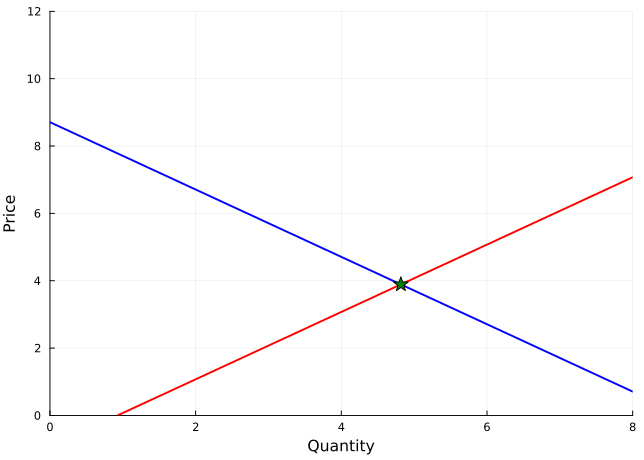

**With** the theory of supply and demand, you and understand that each point is the simultaneous equilibrium outcome of two underlying structural relationships in equilibrium. [Phillip and / or Sewall Wright proposed the solution](https://mixtape.scunning.com/07-instrumental_variables): Instrumtal Variables, which is perhaps the earliest known example of an estimated structural model.

### 6.2.4 When variation does not identify the counterfactual of interest

In our examples above, you may have noted that we were careful to very specifically define the “treatment” in order to specify the causal object of interest. Models can help us articulate just exactly what kind of causal parameters can and cannot be identified by observed variation, as well as outlining a specific set of assumptions under which related counterfactuals can be forecast even though they are not exactly replicated by existing variation. Each section below discussed a number of examples in the context of each application. Researchers often frame this as a question of *internal vs external validity*, but there are too many interesting examples in the “external validity” column to not discuss them in more depth. In general, a key point made by Heckman and Vytlacil (2005) is that estimands from simple statistical mdoels designed to infer causal effects (such as those we get from difference-in-differences, IV, and regression discontinuity) are rarely parameters of exact policy interest.

We’ll use examples to explore these ideas.

#### 6.2.4.1 Social Security

To make the example concrete, let’s make some additional simplifying assumptions for the savings model. These make the quantitative model a bit less interesting, but help us think through the issues. Specifically, let’s assume:

1. Each individual faces a *known* sequence $\{y_{n,t}\}_{t=1}^{T}$ of income realizations.
2. Agents face a *natural borrowing constraint*, yielding an intertemporal borrowing constraint at each $t$:
   $$\sum_{s=t}^{T}q_{s-t}c_{s} \leq a_{t} + \sum_{s=t}^{T}q_{s-t}(1-\tau)y_{n,s} + \sum_{s\geq 65}^{T}q_{s-t}b$$
   where $q_{\tau} = 1/(1+r)^{\tau}$ is the price of a unit of consumption $\tau$ periods ahead.
3. Set $\beta(1+r)=1$, and $\psi=0$ (no bequest motive), indicating that agents will elect to perfectly smoooth their consumption over periods so that consumption is equal to the net present value of net income (something they can do due to the natural borrowing constraint).

With these assumptions, we can write the mean effect on consumption for cohort $t^*$ at any age $t\geq t^*$ as simply the effect of the announcement on the NPV of net income at age $t^*$:

$$\Delta C_{t^*,t} = \sum_{s=60}^{64}q_{s-t^*}b + \sum_{s=t^*}^{T}(\tau - \tau')\overline{y}_{t^*,t}$$
where $\overline{y}_{t^*,t}$ is average income for cohort $t^*$ at age $t$.

With these assumptions, note that:

1. The parallel trends assumption holds: under the counterfactual of no policy change, differences across cohorts are constant with age ($\mu_{t}$ can be normalized to zero).
2. The difference-in-difference approach therefore robustly identifies, with $\alpha_{t^*,t}$, the causal effect of the policy on cohort $t^*$ at age $t$.
3. The model implies that $\alpha_{t^*,t}$ is constant with $t$.
4. Each effect depends on **how each cohort $t^*$ expects the policy expansion to be financed**, through the change in marginal tax rates $\tau' - \tau$. We haven’t specified financing constraints and hence we cannot speculate on this without more structure.

Are the parameters $\alpha_{t^*,t}$ policy relevant quantities? They are certainly informative, but now that eligibility has been expanded, these effects don’t tell us about the effect of future changes in policy. They don’t even (without additional assumptions) tell us what the effect would be if the expansion were repealed. We need more theory and assumptions to extrapolate. This is a good task for economic models!

#### 6.2.4.2 Tax Reform

1. The average treatment effect depends on income effects, which in turn depend on the perceived length of time that the tax reform is enforced.
2. The model exhibits lots of heterogeneity in treatment effects. As such, if there are differences in underlying distributions of wages or work costs, we should expect different impacts.

Thus, although each welfare experiment robustly identifies the effect of tax reform $A$ and population $A$, tax reform $B$ on population $B$, and so forth. It does not identify:

1. The effect of any tax reform with different persistence (real or perceived). Moreover, one would want to interpret the experimental findings very carefully to ensure that individuals in the experiment were given adequate information about the length of time of the experiment.
2. The effect of tax reform $A$ on population $B$, $C$, etc, and likewise for tax reforms $B$, $C$, etc on alternative populations.
3. The distribution of treatment effects at each location.
4. The effect of tax reforms that are *already partly anticipated* by individuals.
5. The effect of a scaled up tax reform, where *equilibrium effects* on wages might appear.
6. The distribution of effects of each tax reform. Here the model can be used to be interpret available panel data and invert out distributions in observed labor market productivities and work costs. One can then return to the experimental data and estimate average treatment effects along these latent dimensions.

#### 6.2.4.3 Entry-Exit Model

By now we have made the point several ways, but when it comes to the model of dynamic duopoly, we can note that the model-free approach does not identify:

1. The effect of the minimum wage policy when it’s introduction is anticipated several periods earlier.
2. The effect of the minimum wage on the markets that do not adopt it.
3. The effect of repealing the minimum wage.
4. The effect of nominal changes to the minimum wage.

Each of which might be considered much more useful or compelling policy calculations.

### 6.2.5 To interpolate existing variation in the data

Sticking with the tax reform example, let’s consider what it would take to jointly understand the effects. We know that each reform is related because each comes in the form of an infinite dimensional object: a function $\mathcal{T}(W,H)$ of wages and hours. A model-free theory that attempts to estimate labor supply as a non-parametric function of this function would not get very far due to the implausible quantities of policy variation that would be needed to estimate it.

Economic models often provide a useful way to interpolate related – but not functionally identically related – variation. Notice that in the labor supply model any function $\mathcal{T}$ is articulated through its effect on the budget constraint, and different policy reforms can be compared in the model without the addition of any new parameters. I refer to this property as *articulated variation*: when the effect of a variable can be modeled without the need for additional parameters. Typically, this involves *a priori* known changes to prices and endowments.

Here is a useful *counterexample*: policy variation that is not well-articulated inside a model. Consider our choice of modeling the minimum wage in our entry and exit model: embodied as a parameter $\phi_{4}$. Our choice to not model within-period production decisions of the firm (and instead estimate a reduced form) means that this policy is *not* well-articulated. We need an additional parameter $\phi_{4}$ to model its effect, and further changes to the nominal wage cannot be studied.

## 6.3 Marschak’s Maxim

Our discussion so far has focused on exploring the boundaries of what simpler causal inference strategies can identify in order to make statements about how economic modeling can add value in research. This is not very instructive for *how* we do economic modeling. Of course this topic is more of an art than a science, but Marschak’s Maxim (Marschak 1953; Heckman and Vytlacil 2007) is a useful principle that can guide us. Here it is:

> Researchers should specify the minimal set of model ingredients in order to answer the research question of interest.

This may seem obvious, and that the hard part is figuring out what this minimal set is. It’s true that this can be hard to decide, but it’s surprisingly easy to forget this simple rule once you are deep inside your model and making decisions. The question “Is this essential to my question of interest?” is not always easy to answer but it is one you should be repeatedly asking yourself. Your research question is the mast you tie yourself to, and you should decide as early as possible what it is.

### 6.3.1 Marschak’s Original Example

### 6.3.2 Two-Stage Budgeting

### 6.3.3 Sufficient Statistics

Goodman-Bacon, Andrew. 2021. “Difference-in-Differences with Variation in Treatment Timing.” *Journal of Econometrics* 225 (2): 254–77. https://doi.org/https://doi.org/10.1016/j.jeconom.2021.03.014.

Heckman, James, and Edward Vytlacil. 2005. “Structural equations, treatment effects, and econometric policy evaluation.” *Econometrica* 73 (3): 669–738.

———. 2007. “Chapter 70 Econometric Evaluation of Social Programs, Part i: Causal Models, Structural Models and Econometric Policy Evaluation.” In, edited by James J. Heckman and Edward E. Leamer, 6:4779–874. Handbook of Econometrics. Elsevier. https://doi.org/https://doi.org/10.1016/S1573-4412(07)06070-9.

Marschak, Jacob. 1953. “Economic Measurements for Policy and Prediction.” In *Studies in Econometric Method*, edited by W. Hood and C. Koopmans. John Wiley & Sons.

Mullins, Joseph. 2026. “A Structural Meta-Analysis of Welfare Reform Experiments and Their Impacts on Children.” *Journal of Political Economy* 134 (1): 435–77. https://doi.org/10.1086/738482.